# 2.ts-decompose

Bongus

2019 4 30

# 분해법

1. 이동평균법 - 단순이동평: 단순평균
- 이동평균은 Smoothing의 방법중 하나. 추세를 확실히 파악하기 위해선 등락을 제거하고 보는 방법이 있다. 등락을 제거하는 방법 중 하나가 이동평균.
- 자잘한 변동을 없애고 흐름을 파악하는 것.
- 과거의 어떤 기간을 정해 평균을 구하는 것.
2. 이동평균 그리기: filter함수를 이용해 R에서 단순 이동평균을 그릴 수 있다.

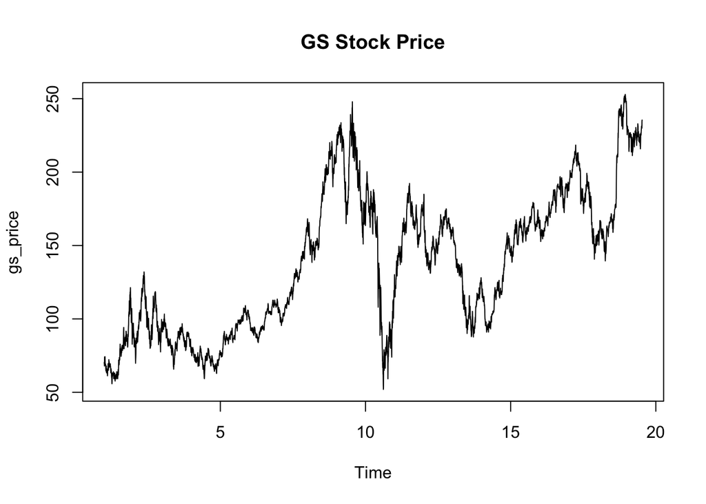

```r
# 단순이동평균
gs <- read.csv('./data/gs_ts.csv')
gs_price <- ts(gs$price, frequency = 250)
# 시계열분석을 위해 ts type으로 변환.
# freq => 주기라고 생각
# freq 250의 의미? 주가 데이터는 영업일 기준으로 기록.
# 일주일 5일 1년 250일정도 기록이 되는 것으로.
# 즉, 1년마다 반독되는 주기가 있을 것이란 가설. 계절성을 부여하는 것.
# 정답이 있는 것이 아니고 사전적 지식, 혹은 합리적 추정을 통해 결정해야하는 부분

plot(gs_price, main="GS Stock Price")
```

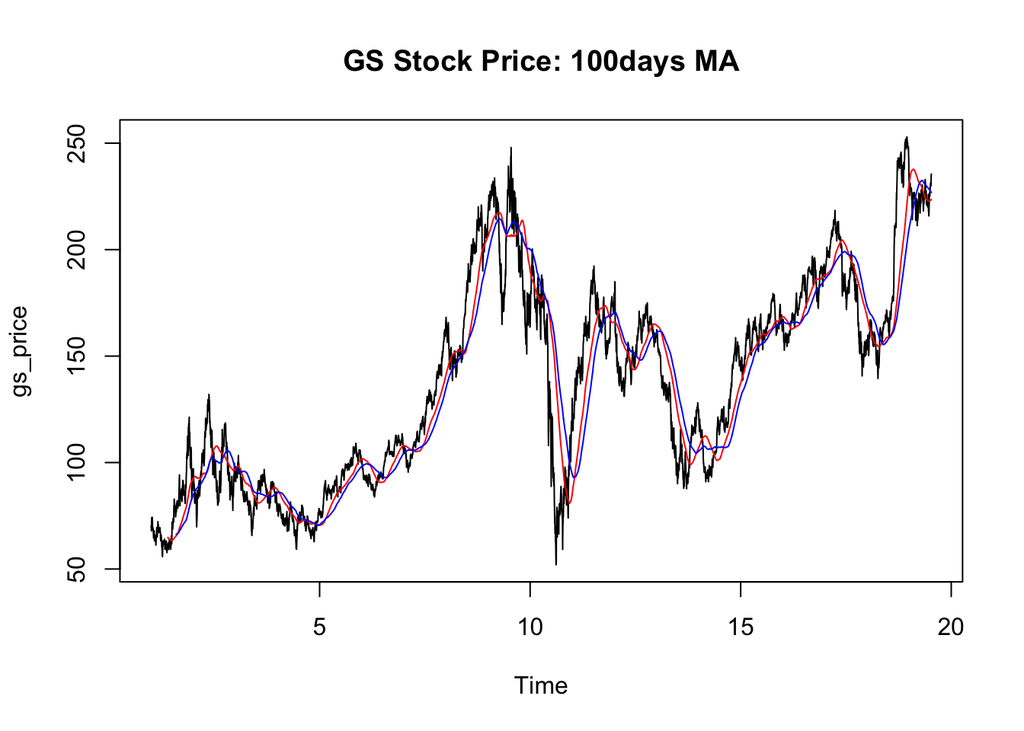

```r
# moving avg => 변동이 많은 데이터를 부드럽게해서 추세를 파악하기 위한 용도.
plot(gs_price, main="GS Stock Price: 100days MA")
ml <- filter(gs_price, rep(1/100, 100), sides= 1)
ml2 <- filter(gs_price, rep(1/150, 150), sides= 1)
lines(ml, col="red")
lines(ml2, col="blue")
```

변동이 많은 데이터를 부드럽게해서 추세를 파악하기 위한 용도.

3. 이동평균법 - 지수이동평균
- 단순이동평군과 달리 지수이동평균은 평균을 할 떄 가중치를 다르게 적용
- 현지점 데이터의 가중치(alpha)를 정하면 나머지는 자동적으로 계산되어 적용
- 가중치는 0, 1의 값
- 최근일수록 가중치가 높고, 나중으로 갈수록 가중치가 작아짐.
- HoltWinters 함수를 사용 -> 가중치 alpha를 설정하면 자동으로 나머지 가중치 값이 결정
- HoltWinters는 시계열을 Level(alpha), Trend(beta), Seasonality(gamma)로 분열

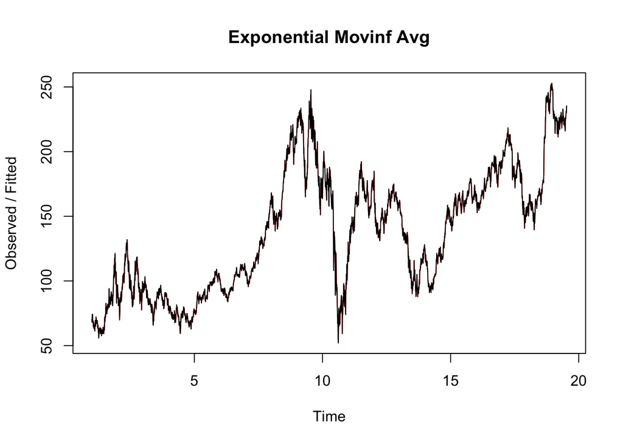

```r
# exponential moving avg
# HoltWinters => 기본함수
gs_hw <- HoltWinters(gs_price, beta=F, gamma=F)
plot(gs_hw, main="Exponential Movinf Avg")
```

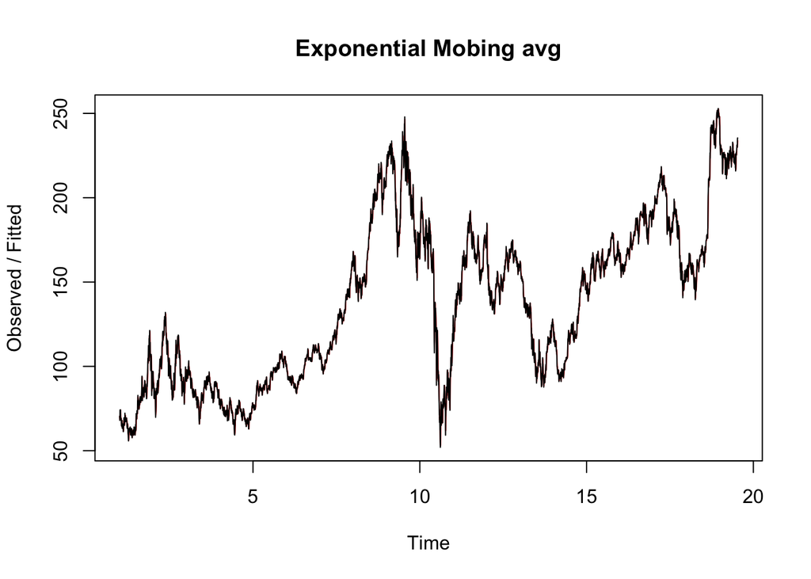

```r
# Weight is fixed: HoltWinters
gs_exp <- HoltWinters(gs_price, alpha = 0.8, beta=F, gamma=F)
plot(gs_exp, main="Exponential Mobing avg")
```

4. 시계열의 분해
- 트렌드
- 계절성
- **나머지: 트렌드, 계절성을 제외**

  시계열의 분해는 크게 트렌드와 계절성으로 쪼개는 것을 의미.
5. 분해가 왜 필요한가?
- 수학, 통계의 접근법: 그 상태에서 어렵다면 해결할 수 있는 형태로 변화가 필요.
- 더 쉬운형태로 변환해서 문제를 해결
- 원 시계열을 그대로 분석하는 것보다 몇 개의 요소로 구성되어 있다고보고 원 시계열을 요소별로 나눠서 생각해보자는 것.
- 사실 트렌드와 계절성은 가정이지만, 합리적 가정이라면 시계열 데이터를 분석하는데 도움이 될수도 있다.
6. 시계열의 계절성
- freq => 주기라고 생각: freq tunning이 중요.
- freq 250의 의미? 주가 데이터는 영업일 기준으로 기록.
- 일주일 5일 1년 250일정도 기록이 되는 것으로.
- 즉, 1년마다 반독되는 주기가 있을 것이란 가설. 계절성을 부여하는 것.
- 정답이 있는 것이 아니고 사전적 지식, 혹은 합리적 추정을 통해 결정해야하는 부분
- 어떤 freq를 부여했을 때 원하는 결과를 만들어 낼 수 있는가?
7. Holt-Winters
- 분해법에서 많이 쓰는 함수 중 하나.
- Level, Trend, Seasonal
- Level(alpha): 지수이동평균과 유사. 과거시계열을 이동평균.
- Trend(beta): 데이터의 증감, 기울기
- Seasonal(gamma): 반복여부

[output not shown]

8. decompose() - 분해법 함수
- 단순이동평균으로 트렌드를 추출
- 계절성은 ts를 만들 때 freq에 의해 결정
- HoltWinters를통해 decompose()와 같은 결과물을 얻기 위해선 몇가지 작업이 더 필요.
9. HoltWinters - decompose

```r
gs_hw <- HoltWinters(gs_price, beta=0.5) # list 형식
is.list(gs_hw)
```

```
## [1] TRUE
```

```r
attributes(gs_hw) # gs_hw에 어떤 요소들이 있는지 확인 가능.
```

```
## $names
## [1] "fitted"       "x"            "alpha"        "beta"
## [5] "gamma"        "coefficients" "seasonal"     "SSE"
## [9] "call"
##
## $class
## [1] "HoltWinters"
```

```r
str(gs_hw)
```

```
## List of 9
##  $ fitted      : Time-Series [1:4383, 1:4] from 2 to 19.5: 71 103.1 100.8 95.9 92.4 ...
##   ..- attr(*, "dimnames")=List of 2
##   .. ..$ : NULL
##   .. ..$ : chr [1:4] "xhat" "level" "trend" "season"
##  $ x           : Time-Series [1:4633] from 1 to 19.5: 70.4 69.1 67.9 74.1 70.7 ...
##  $ alpha       : Named num 0.849
##   ..- attr(*, "names")= chr "alpha"
##  $ beta        : num 0.5
##  $ gamma       : Named num 0.536
##   ..- attr(*, "names")= chr "gamma"
##  $ coefficients: Named num [1:252] 243.09 -0.443 -7.499 -8.792 -7.378 ...
##   ..- attr(*, "names")= chr [1:252] "a" "b" "s1" "s2" ...
##  $ seasonal    : chr "additive"
##  $ SSE         : num 86039
##  $ call        : language HoltWinters(x = gs_price, beta = 0.5)
##  - attr(*, "class")= chr "HoltWinters"
```

```r
gs_hw_fitted <- gs_hw$fitted[, 1:4] # fitting된 데이터 추출.
head(gs_hw_fitted)
```

```
##           xhat     level     trend     season
## [1,]  71.03434  77.35242 0.1119371  -6.430015
## [2,] 103.09577  96.32901 9.5442668  -2.777515
## [3,] 100.78199 100.69700 6.9561251  -6.871135
## [4,]  95.85388 101.04497 3.6520470  -8.843135
## [5,]  92.43407 100.68568 1.6463816  -9.897995
## [6,]  90.80673 100.42649 0.6935941 -10.313355
```

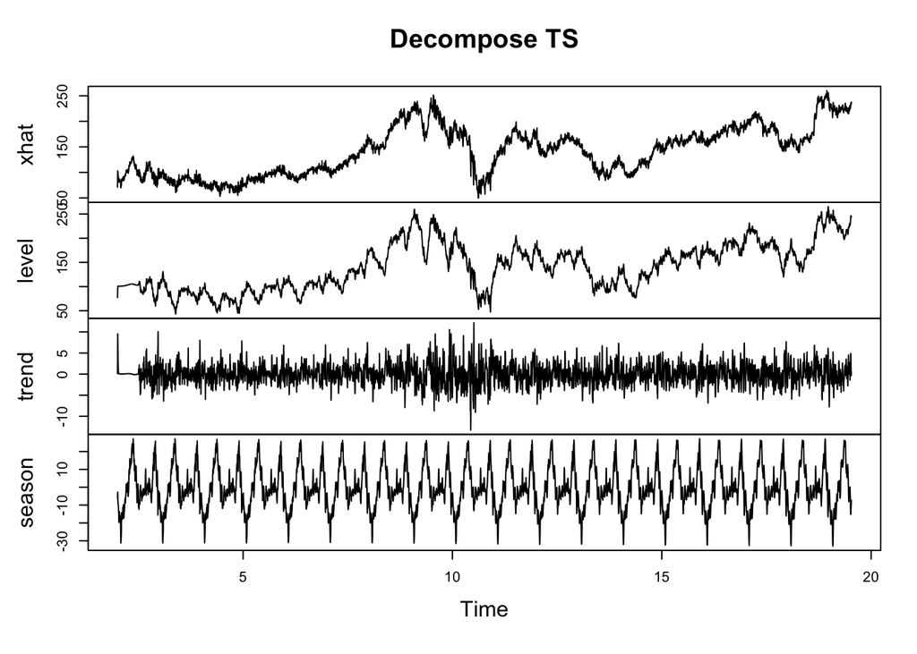

```r
plot(gs_hw_fitted, main="Decompose TS")
```

10. STL(Seasonal Decomposition of Time Series by LOESS)
- loess: LOcal rEgreSSion <- LOWESS: locally weighted scatter polt smoother
- 일반적으로 LOWESS: locally weighted polynomial regression으로 불림
- Local polynomial regression: x(0) 근처 데이터들을 polynomial로 fitting. 나눈 구간의 중심?
- stl() 함수를 사용
- LOWESS
- 비모수회귀분석(non-parametric regression)

```r
library(forecast)
```

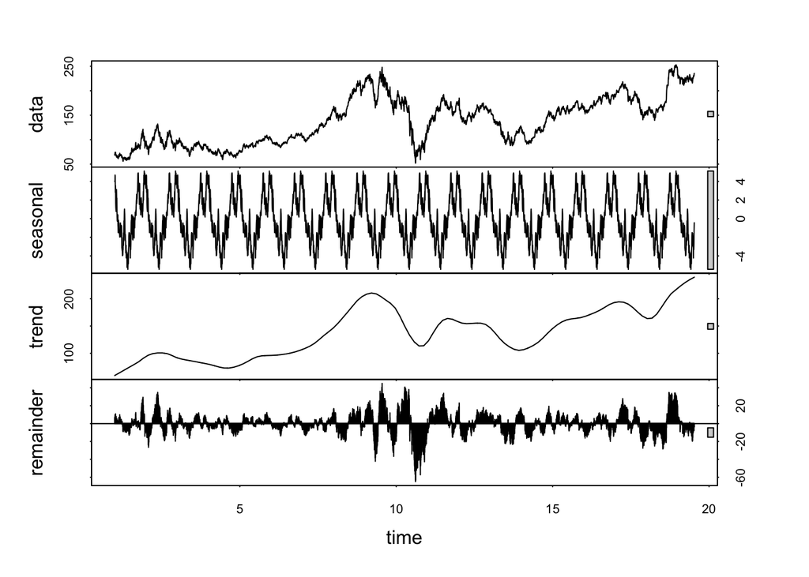

```r
library(ggplot2)
gs_stl <- stl(gs_price, s.window="periodic")
plot(gs_stl)
```

```r
stl_forecast <- forecast(gs_stl, h = 100) # 예측
attributes(stl_forecast)
```

```
## $names
##  [1] "model"     "mean"      "level"     "x"         "upper"
##  [6] "lower"     "fitted"    "method"    "series"    "residuals"
##
## $class
## [1] "forecast"
```

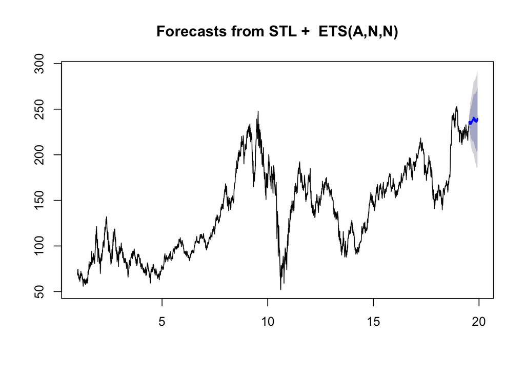

```r
plot(stl_forecast)
```

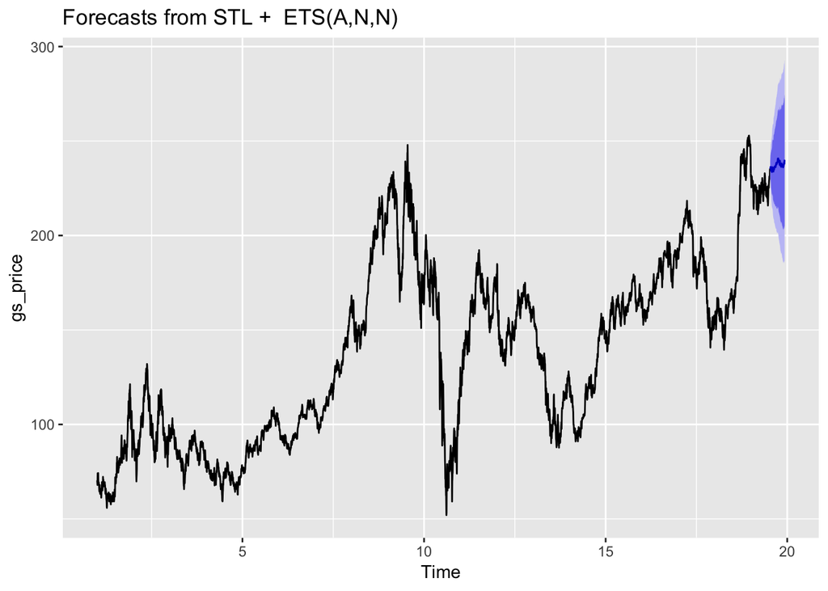

```r
autoplot(stl_forecast)
```

# 시계열 예측

1. 시계열 분해법을 기반으로 시게열 예측이 가능하다.
2. 시계열예측은 분해법말고도 ARIMA와 같은 여러가지 다른 모델들이 존재한다.
3. 에측모형 만드는 과정
- 데이터를 나눔
- Training data: 예측모형 구현용 데이터(fit)
- Test data: 구현된 모형의 성능을 테스트(Accurancy), 모델링에 사용되지 않은 데이터.
- 나누는 기준은 어떤 모형을 만드느냐에 따라 달라진다.
4. 모형성능 및 예측정확도 측정
- MSE(Mean Squared Error): MSE가 낮을 모형이 설명력이 높음. 실측값과 예측값 사이의 분산.
- fitted value라고 부르기도 함. trainig set에 있는 데이터를 사용. (모형의 설명력)
- MAPE(Mean Absolute Percentage Error): MAPE가 낮은 모형이 정확도가 우수(forecasting). 1-MAPE = 정확도. 분모: 실측, 분자: 실측-예측. Error의 Percentage가 어느정도 되는가? (예측의 정확도)
- 정확도: 1-MAPE = mean(100 - 100 * abs((RealValue - ForecastedValue) / RealValue))
5. 예측모형의 성능: Cross Validation for Prediction(회귀분석 및 지도학습): k-fold cross validation 순서
- 1. 데이터에서 정해진 크기의 테스트 데이터를 랜덤하게 추출
- 2. 추출한 나머지를 트레이닝 데이터로 정하고 모델링 진행
- 3. 결과 모델을 추출한 테스트데이터로 검증
- 4. 1,2,3을 k번 반복. 단 테스트 데이터들은 서로 배타적.
6. 시계열은 조금 다른 특징이 있다: 시계열은 순서 자체에 의미가 있기 때문에 랜덤허게 데이터를 뽑으면 문제가 생길 수 있다.
- 1. 데이터에서 정해진 크기의 테스트 데이터를 추출
- 2. 테스트 데이터 이전 데이터를 트레이닝 데이터로 정하고 예측 모델링 진행
- 3. 결과 모델을 추출한 테스트데이터로 비교, 검증
- 4. 1,2,3을 다른 시간대별로 수행
7. 만드는 순서
- 데이터 준비
- 1.1. 데이터요건정의: 활용가능데이터/예측기간/단위(일, 분, 분기) 등
- 1.2. 대상시계열외 기타 연관정보/데이터 조사 및 확보
- 1.3. 모델링이 가능한 구조로 정제
- 모델링
- 2.1. 밥법론별 모델 Training 및 예측(Training set): 여러개의 알고리즘을 사용.
- 2.2. 퍼포먼스측정/비교(Test set)
- 모형구축
- 3.1. 튜닝을 통한 예측력증대
- 3.2. 최종모형구축 및 리포팅

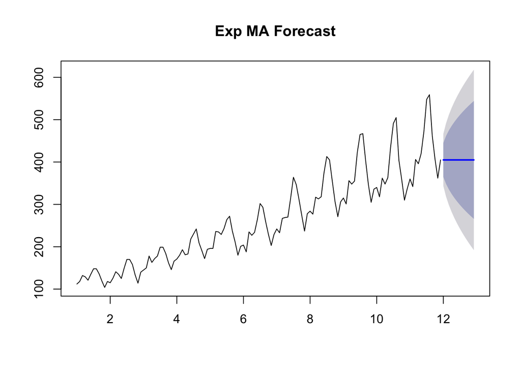

```r
# 시계열 예측: AirPassenger Data
# 이동평균 예측
# 데이터를 모형을 위한 Training, Test로 구분
#   얼마나 예측을 하고 싶은가를 먼저 결정해야함.
#   12개월 후의 데이터를 예측하고 싶으면, 테스트 데이터는 최근 12개를 테스트셋트로 설정
# 예측 모형들로 각각 예측을 수행
# 정확도를 산출하여 성능측정
ap <- AirPassengers
ap_ms <- ap[1:132] # Modeling set
ap_ts <- ap[133:144] # Test set

y <- ts(ap_ms, frequency = 12) # ts로 변환

# Exponential Moving Avg: 장기예측에 유용하지 않을 수 있다. 하지만 현업에서 Exp MA를 많이 사용. 바로 다음달, 바로 다음분기, 즉 하나의 포인트 예측을 하기 위한 Exp MA를 사용하기도 한다.
# Exponential Moving Avg 1
fit <- HoltWinters(y, beta=F, gamma=F) # Exp.MA Learning. Level만 고려하면 Exp MA
fc <- forecast(fit, h=12)
plot(fc, main="Exp MA Forecast")
```

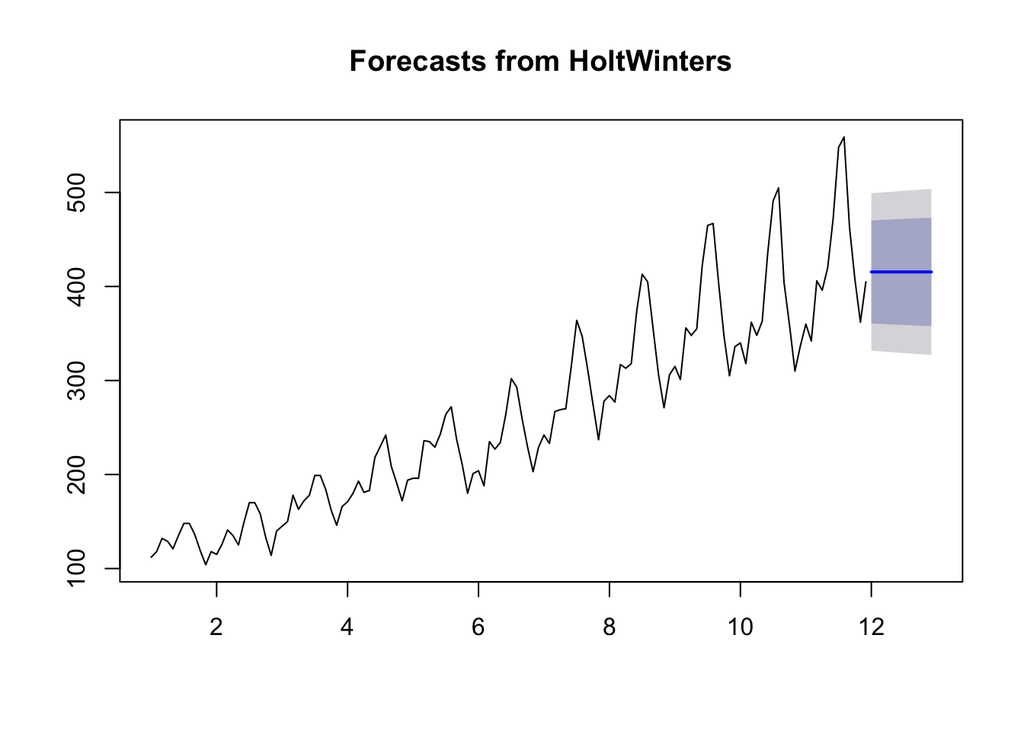

```r
# Exponential Moving Avg 2: alpha가장 최근 데이터에 주는 가중치
fit2 <- HoltWinters(y, alpha=0.1, beta=F, gamma=F) # Exp.MA Learning. Level만 고려하면 Exp MA
fc2 <- forecast(fit2, h=12)
plot(fc2)
```

```r
# 1-MAPE
mean(100 - 100*abs((as.numeric(fc$mean - as.numeric(ap_ts)))/as.numeric(ap_ts)))
```

```
## [1] 85.74829
```

```r
mean(100 - 100*abs((as.numeric(fc2$mean - as.numeric(ap_ts)))/as.numeric(ap_ts)))
```

```
## [1] 87.10142
```

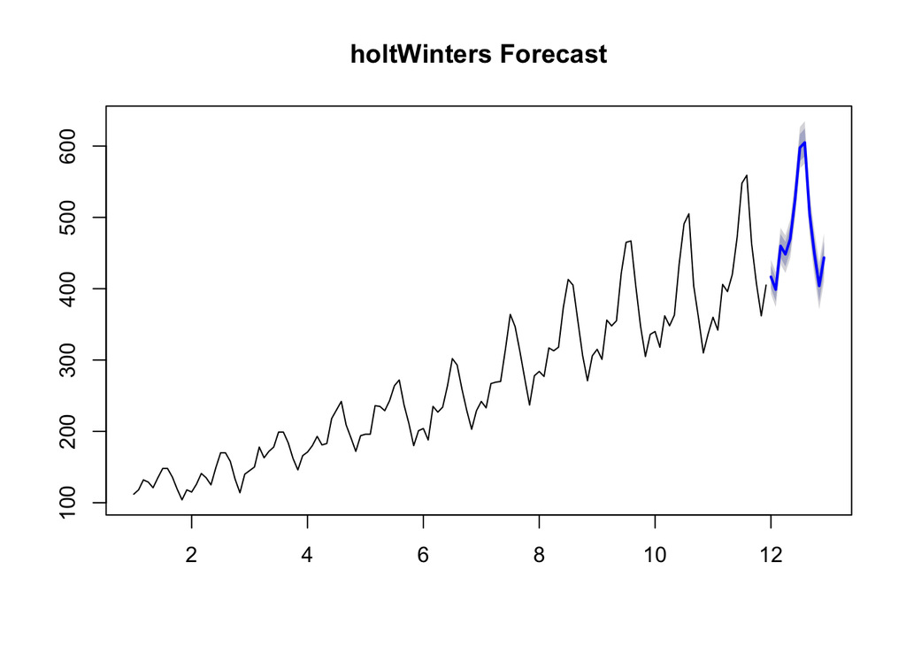

```r
# HoltWinters 예측
# HoltWinters 함수: HoltWinters ,hw -> tend, seasonal 고려
# HoltWinters
fit3 <- HoltWinters(y)
fc3 <- forecast(fit3, h=12)
plot(fc3, main='holtWinters Forecast')
```

```r
mean(100 - 100*abs((as.numeric(fc3$mean - as.numeric(ap_ts)))/as.numeric(ap_ts)))
```

```
## [1] 97.48
```

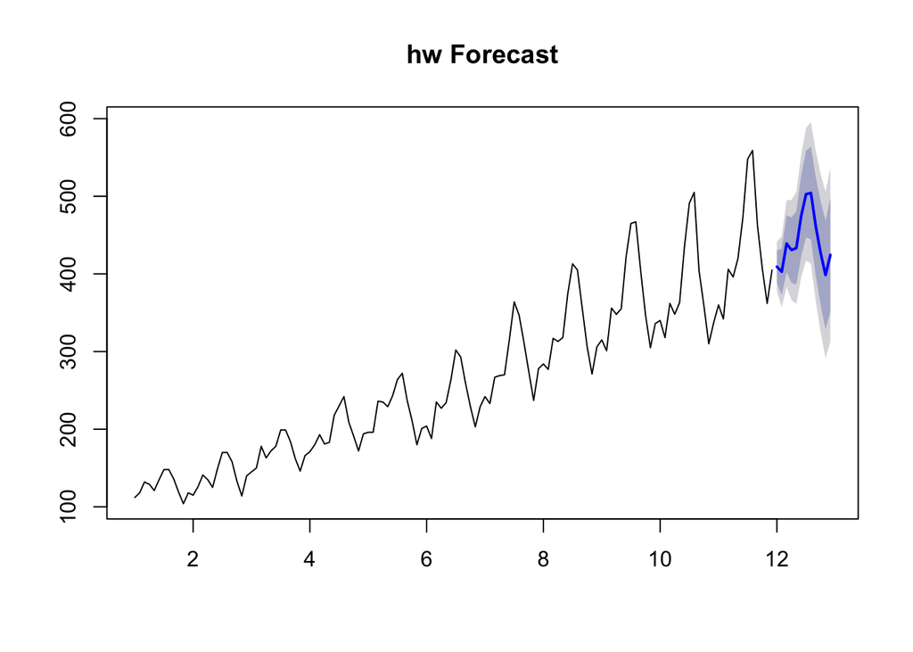

```r
# hw: frequncy가 높으면 최적화가 잘 안되는 경우가 있음. < 25
fit4 <- hw(y)
fc4 <- forecast(fit4, h=12)
plot(fc4, main='hw Forecast')
```

```r
mean(100 - 100*abs((as.numeric(fc4$mean - as.numeric(ap_ts)))/as.numeric(ap_ts)))
```

```
## [1] 92.31096
```

```r
# hw vs Holtwinters
# 알고리즘을 추정하는 파라미터의 설정에 차이가 있다.
# Holtwinters: alpha, beta, gamma - MSE를 최소로하는 알고리즘
# hw: alpha, beta, gamma - MLE를 높이는 알고리즘
```

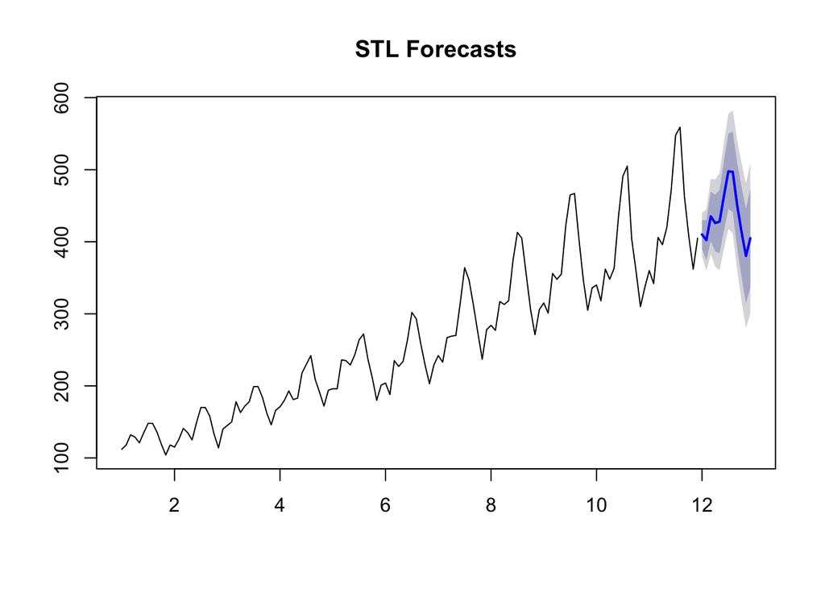

```r
# STL
# STL(Seasonal Decomposition of Time Series by LOESS)
fit5 <- stl(y, s.window = "per")
fc5 <- forecast(fit5, h=12)
plot(fc5, main='STL Forecasts')
```

```r
mean(100 - 100*abs((as.numeric(fc5$mean - as.numeric(ap_ts)))/as.numeric(ap_ts)))
```

```
## [1] 91.09606
```

8. 다른 데이터를 이용한 예측: 미국실업률

```r
# 다른 데이터를 이용한 예측: 미국 실업률
us_unemploy <- read.csv('./data/USunemp.csv')
dim(us_unemploy)
```

```
## [1] 130   1
```

```r
us_ms <- us_unemploy$USun[1:118]
us_ts <- us_unemploy$USun[119:130]
y <- ts(us_ms, frequency = 12)

par(mfrow=c(4,1))
# Exp MA
fit6 <- HoltWinters(y, beta=F, gamma = F)
fc6 <- forecast(fit6, h=12)
plot(fc6, main="Exp MA")
mean(100 - 100*abs((as.numeric(fc6$mean - as.numeric(us_ts)))/as.numeric(us_ts)))
```

```
## [1] 95.09453
```

```r
# HW
fit7 <- HoltWinters(y)
fc7 <- forecast(fit7, h=12)
plot(fc7)
mean(100 - 100*abs((as.numeric(fc7$mean - as.numeric(us_ts)))/as.numeric(us_ts)))
```

```
## [1] 97.05941
```

```r
fit8 <- hw(y)
fc8 <- forecast(fit8, h=12)
plot(fc8, main='Holt Winters')
mean(100 - 100*abs((as.numeric(fc8$mean - as.numeric(us_ts)))/as.numeric(us_ts)))
```

```
## [1] 98.63304
```

[figure not shown]

```r
# STL
fit9 <- stl(y, s.window = "periodic")
fc9 <- forecast(fit9, h=12)
plot(fc9, main='STL Forecasts')
```

```r
mean(100 - 100*abs((as.numeric(fc9$mean - as.numeric(us_ts)))/as.numeric(us_ts)))
```

```
## [1] 96.05077
```

9. 다른 데이터를 이용한 예측: 뉴질랜드 환율

```r
# 다른 데이터를 이용한 예측: 뉴질랜드환율(분기데이터)
newzil <- read.csv('./data/pounds_nz.csv')
dim(newzil)
```

```
## [1] 39  1
```

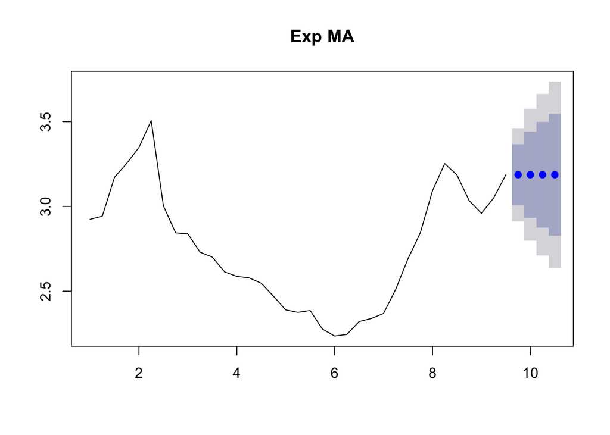

```r
newzil_ms <- newzil$xrate[1:35]
newzil_ts <- newzil$xrate[36:dim(newzil)[1]]

y <- ts(newzil_ms, frequency = 4)
# 정확도 함수
# MAPE(Mean Absolute Percentage Error): MAPE가 낮은 모형이 정확도가 우수(forecasting). 1-MAPE = 정확도. 분모: 실측, 분자: 실측-예측. Error의 Percentage가 어느정도 되는가? (예측의 정확도)

# 정확도: 1-MAPE = mean(100 - 100 * abs((RealValue - ForecastedValue) / RealValue))
accurancy <- function(forecasting, test) {
  value <- mean(100 - 100*abs((as.numeric(forecasting$mean - as.numeric(test)))/as.numeric(test)))
  return(value)
}

# EXP MA
n_fit1 <- HoltWinters(y, beta=F, gamma=F)
n_fc1 <- forecast(n_fit1, h=4)
plot(n_fc1, main="Exp MA")
```

```r
accurancy(n_fc1, newzil_ts)
```

```
## [1] 95.96399
```

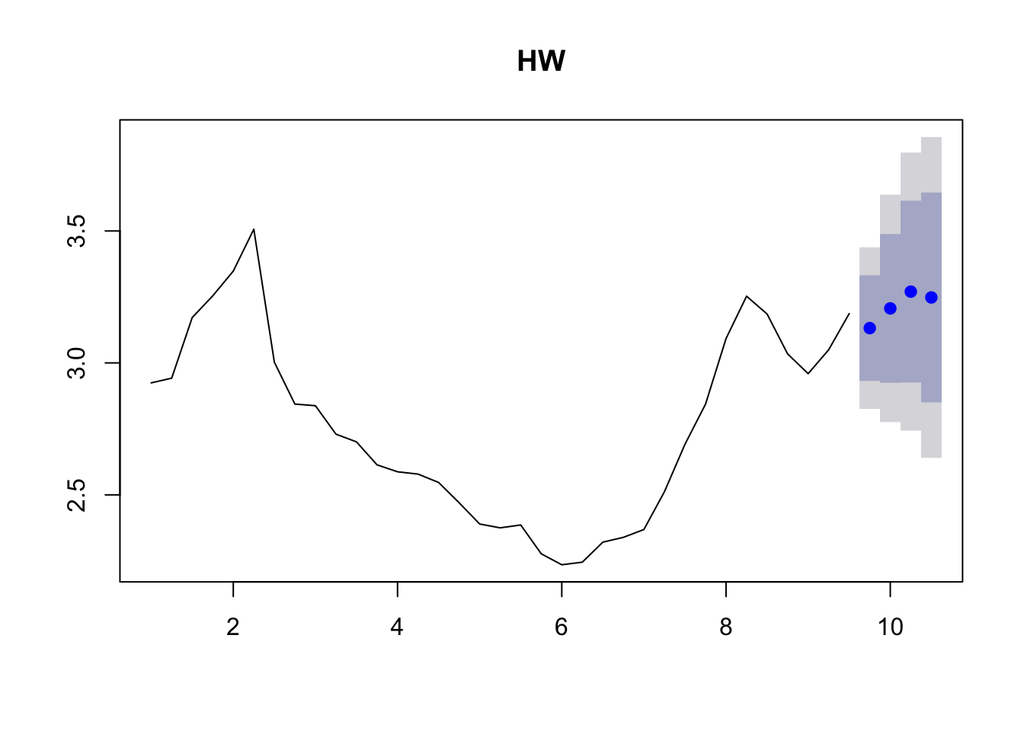

```r
# HW
n_fit2 <- hw(y)
n_fc2 <- forecast(n_fit2, h=4)
plot(n_fc2, main="HW")
```

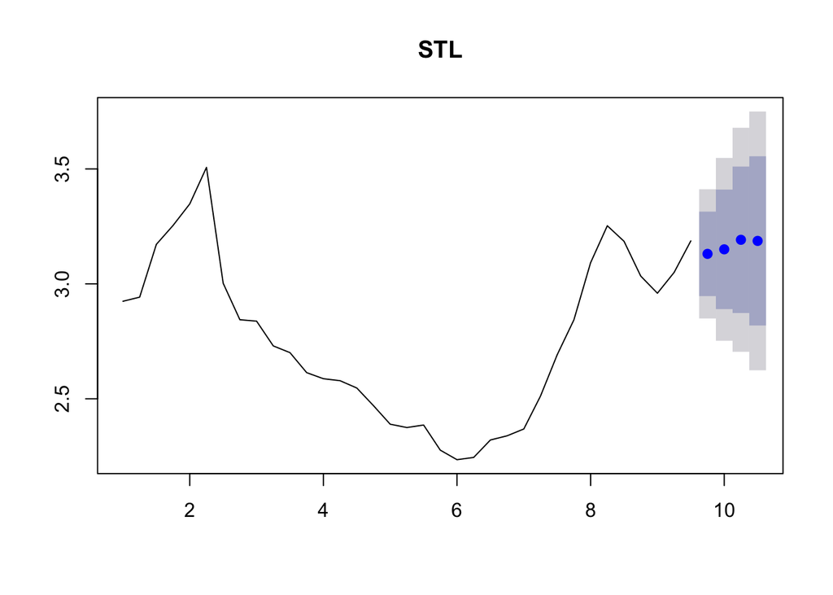

```r
# STL
n_fit3 <- stl(y, s.window = 'periodic')
n_fc3 <- forecast(n_fit3, h=4)
plot(n_fc3, main="STL")
```